# R-Tips Notebook

## Useful Links

- [R for Data Science](https://r4ds.had.co.nz/)
- [Definitive Guide to Notebooks/Markdown](https://bookdown.org/yihui/rmarkdown/markdown-syntax.html)
- [knitr options](http://yihui.name/knitr/options/)
- [R Markdown Templates](https://github.com/dr-harper/example-rmd-templates)
- [Github with Rstudio](http://happygitwithr.com/rstudio-git-github.html)
- [papaja](https://crsh.github.io/papaja_man/index.html)

## Example

First, load in all necessary packages as well as the data.

```r
  #section 2.6.1 of Definitive Guide
library(lavaan)
library(tidyverse) #managing data
library(broom) #cleaning output
library(semPlot) #creating path diagrams
library(sjPlot) #for plotting things
df<-read.csv("ECLSK2011 PSYC 501.csv")
```

We will be using an example right from class. Examining a quadratic growth model.

```r
gc.q.math<-"
i=~ 1*x2_math + 1*x4_math + 1*x6_math + 1*x7_math + 1*x8_math
sl=~ 0*x2_math + 1*x4_math + 2*x6_math + 3*x7_math + 4*x8_math
sq=~ 0*x2_math + 1*x4_math + 4*x6_math + 9*x7_math + 16*x8_math
"
gc.q.math.fit<-growth(gc.q.math,data=df, missing="fiml")
summary(gc.q.math.fit, fit.measures=T, standardized=T)
```

```
## lavaan 0.6-3 ended normally after 158 iterations
##
##   Optimization method                           NLMINB
##   Number of free parameters                         14
##
##                                                   Used       Total
##   Number of observations                         17486       18174
##   Number of missing patterns                        29
##
##   Estimator                                         ML
##   Model Fit Test Statistic                    1318.218
##   Degrees of freedom                                 6
##   P-value (Chi-square)                           0.000
##
## Model test baseline model:
##
##   Minimum Function Test Statistic            77475.960
##   Degrees of freedom                                10
##   P-value                                        0.000
##
## User model versus baseline model:
##
##   Comparative Fit Index (CFI)                    0.983
##   Tucker-Lewis Index (TLI)                       0.972
##
## Loglikelihood and Information Criteria:
##
##   Loglikelihood user model (H0)             -257458.122
##   Loglikelihood unrestricted model (H1)     -256799.013
##
##   Number of free parameters                         14
##   Akaike (AIC)                              514944.244
##   Bayesian (BIC)                            515053.012
##   Sample-size adjusted Bayesian (BIC)       515008.521
##
## Root Mean Square Error of Approximation:
##
##   RMSEA                                          0.112
##   90 Percent Confidence Interval          0.107  0.117
##   P-value RMSEA <= 0.05                          0.000
```

[output cut: 46 more lines]

```
##    .x8_math           0.000                               0.000    0.000
##     i                48.473    0.097  497.374    0.000    3.841    3.841
##     sl               25.350    0.068  375.013    0.000    3.908    3.908
##     sq               -2.597    0.015 -172.176    0.000   -2.130   -2.130
##
## Variances:
##                    Estimate  Std.Err  z-value  P(>|z|)   Std.lv  Std.all
##    .x2_math           5.430    1.281    4.239    0.000    5.430    0.033
##    .x4_math          58.796    0.860   68.338    0.000   58.796    0.219
##    .x6_math          30.549    0.652   46.833    0.000   30.549    0.107
##    .x7_math          26.220    0.604   43.417    0.000   26.220    0.092
##    .x8_math          22.762    1.188   19.153    0.000   22.762    0.095
##     i               159.262    2.015   79.033    0.000    1.000    1.000
##     sl               42.080    1.245   33.803    0.000    1.000    1.000
##     sq                1.486    0.057   26.006    0.000    1.000    1.000
```

The output can be somewhat difficult to manage. That is where the `broom` package comes into play using the `tidy()` function.

```r
tidygrow <- tidy(gc.q.math.fit)
#View(tidygrow)

#Create df to reflect just estimates
est <- tidygrow %>%
  filter(std.error>0) %>%
  filter(!grepl('math', term)) %>% #removes all terms that have 'math' in the name
  filter(!grepl('~~',term)) %>% #this is the line that evaluates the op variable
  select(term, estimate, std.error, p.value, std.all)

#create df to reflect only variance
var <- tidygrow %>%
  filter(std.error>0) %>%
  filter(!grepl('math', term)) %>%
  filter(grepl('~~', term)) %>%
  select(term, estimate, std.error, p.value, std.all) %>%
  slice(1:3) #only want the variance

#Combine dataframes
res.qg <- bind_cols(est,var) %>%
  select(term, estimate, std.error, std.all, p.value, estimate1, p.value1)

rownames(res.qg) <- c('Intercept','Linear Slope','Quadratic Slope')
#rounding the estimates
res.qg$estimate <- round(res.qg$estimate, 3)
res.qg$std.error <- round(res.qg$std.error, 3)
res.qg$std.all <- round(res.qg$std.all, 3)
res.qg$estimate1 <- round(res.qg$estimate1, 3)

res.qg <- rownames_to_column(res.qg) %>%
  select(rowname, estimate, std.error, std.all, p.value, estimate1, p.value1)

names(res.qg) <- c('', 'Estimate', 'Std. Error', 'Std. Est.', 'p-value',
                   'Variance','p-value')
tab_df(res.qg, title='Quadratic Parameter Estimates',
       file='QuadParam.html')
```

Quadratic Parameter Estimates

|  | Estimate | Std. Error | Std. Est. | p-value | Variance | p-value |
| --- | --- | --- | --- | --- | --- | --- |
| Intercept | 48.473 | 0.097 | 3.841 | 0 | 159.262 | 0 |
| Linear Slope | 25.35 | 0.068 | 3.908 | 0 | 42.08 | 0 |
| Quadratic Slope | -2.597 | 0.015 | -2.13 | 0 | 1.486 | 0 |

```r
quad <- as.data.frame(fitmeasures(gc.q.math.fit, c("cfi","srmr","rmsea")))
names(quad)[1]<-"Quadratic Growth"
quad$index <- NA
quad[1,2]<-"CFI"
quad[2,2]<-"SRMR"
quad[3,2]<-"RMSEA"
quad[4,2]<-"AIC"
quad[4,1]<-AIC(gc.q.math.fit)
quad[5,2]<-"BIC"
quad[5,1]<-BIC(gc.q.math.fit)
quad$`Quadratic Growth` <- round(quad$`Quadratic Growth`,3)

tab_df(quad, title='Quadratic Growth Fit Stats',
       file = 'QuadFit.html')
```

Quadratic Growth Fit Stats

| Row | Quadratic Growth | index |
| --- | --- | --- |
| cfi | 0.983 | CFI |
| srmr | 0.056 | SRMR |
| rmsea | 0.112 | RMSEA |
| 4 | 514944.244 | AIC |
| 5 | 515053.012 | BIC |

### Correlation Table

Now we know that it is always good to include a correlation table into our manuscripts. But we often forget them until the final piece because we don’t want to have to transfer everything over! Who would want to do that (is that what undergrad RA’s are for??)

This is now a thing of the past! R can do it for you.

```r
#Don't need all of the variables; only select the ones you will be using

cor <- select(df, x1_SES:x8_wght)

#This correlation matrix is too large for the rmarkdown document. Please find it in the folder titled "correlation.html"

sjt.corr(cor,show.p = FALSE, na.deletion = 'pairwise', triangle="upper",
           title = "Correlations",
           CSS=list(css.thead="border-top:double black; font-weight:normal; font-size:0.9em;",
         css.firsttablecol="font-weight:normal; font-size:0.9em;"),file="Correlation.html")
```

### Plots

It is always great to visualize your model. The package [semPlot](http://sachaepskamp.com/documentation/semPlot/semPaths.html) can come in very handy. Let’s take a look:

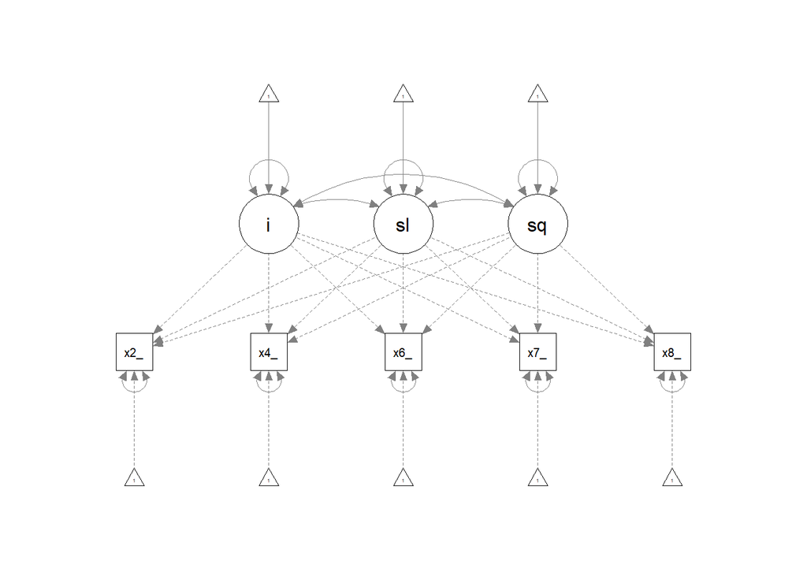

```r
semPaths(gc.q.math.fit, layout='tree2')
```